# Bank Telemarketing Analysis

## I. EDA

```python
# Load and parse the raw semicolon-separated file into a structured table
import pandas as pd
import numpy as np
import warnings
warnings.filterwarnings("ignore")

raw = pd.read_csv("Data.csv", header = None)
split = raw[0].astype(str).str.split(";", expand = True)

split.columns = split.iloc[0].str.strip().str.replace('"', '', regex = False)
data = split.iloc[1:].reset_index(drop = True)
data = data.apply(lambda col: col.str.strip().str.strip('"'))

print("Shape after parsing:", data.shape)
data.head()
```

```
Shape after parsing: (45211, 17)
```

|  | age | job | marital | education | default | balance | housing | loan | contact | day | month | duration | campaign | pdays | previous | poutcome | y |
| --- | --- | --- | --- | --- | --- | --- | --- | --- | --- | --- | --- | --- | --- | --- | --- | --- | --- |
| 0 | 58 | management | married | tertiary | no | 2143 | yes | no | unknown | 5 | may | 261 | 1 | -1 | 0 | unknown | no |
| 1 | 44 | technician | single | secondary | no | 29 | yes | no | unknown | 5 | may | 151 | 1 | -1 | 0 | unknown | no |
| 2 | 33 | entrepreneur | married | secondary | no | 2 | yes | yes | unknown | 5 | may | 76 | 1 | -1 | 0 | unknown | no |
| 3 | 47 | blue-collar | married | unknown | no | 1506 | yes | no | unknown | 5 | may | 92 | 1 | -1 | 0 | unknown | no |
| 4 | 33 | unknown | single | unknown | no | 1 | no | no | unknown | 5 | may | 198 | 1 | -1 | 0 | unknown | no |

```python
# Standardize text columns (strip spaces and lowercase)
obj_cols = data.select_dtypes(include = ["object", "string"]).columns
data[obj_cols] = data[obj_cols].apply(lambda s: s.str.strip().str.lower())
```

```python
# Convert numeric columns to proper numeric types
numeric_cols = ["age", "balance", "day", "duration", "campaign", "pdays", "previous"]
for c in numeric_cols:
    data[c] = pd.to_numeric(data[c], errors = "coerce")
```

```python
# Encode binary yes/no columns as 1/0 (optional for later modeling)
binary_cols = ["default", "housing", "loan", "y"]
data[binary_cols] = data[binary_cols].replace({"yes": 1, "no": 0})
```

```python
# Keep pdays = -1 as a valid value (not previously contacted)
data["previously_contacted"] = (data["pdays"] != -1).astype(int)
```

##### The project is analyzing the subscribtion outcome based on the data before calling customers. Therefore, duration column is not considered when fitting models. Other variables contains unknown will be conducted as one of its categories since those unknowns hold proportion about 20% in the whole dataset. Removing those may cause issues such as overfitting.

```python
# Drop column duration cause the prediction is made before calling
data_clean = data.drop(columns = ["duration"])
data_clean.shape
```

```
(45211, 17)
```

```python
# Final missingness check and save the cleaned dataset
print("Top missing values (final):")
print(data_clean.isna().sum().sort_values(ascending = False).head(10))

data_clean.to_csv("Data_cleaned.csv", index = False)
print("Saved as Data_cleaned.csv")
```

```
Top missing values (final):
0
age         0
day         0
y           0
poutcome    0
previous    0
pdays       0
campaign    0
month       0
contact     0
job         0
dtype: int64
Saved as Data_cleaned.csv
```

```python
# Data overview
print("Shape of cleaned data:", data_clean.shape)
print("\nData types:", data_clean.dtypes)
```

```
Shape of cleaned data: (45211, 17)

Data types: 0
age                      int64
job                     object
marital                 object
education               object
default                  int64
balance                  int64
housing                  int64
loan                     int64
contact                 object
day                      int64
month                   object
campaign                 int64
pdays                    int64
previous                 int64
poutcome                object
y                        int64
previously_contacted     int64
dtype: object
```

```python
print("First 5 rows:\n")
data_clean.head(5)
```

```
First 5 rows:
```

|  | age | job | marital | education | default | balance | housing | loan | contact | day | month | campaign | pdays | previous | poutcome | y | previously_contacted |
| --- | --- | --- | --- | --- | --- | --- | --- | --- | --- | --- | --- | --- | --- | --- | --- | --- | --- |
| 0 | 58 | management | married | tertiary | 0 | 2143 | 1 | 0 | unknown | 5 | may | 1 | -1 | 0 | unknown | 0 | 0 |
| 1 | 44 | technician | single | secondary | 0 | 29 | 1 | 0 | unknown | 5 | may | 1 | -1 | 0 | unknown | 0 | 0 |
| 2 | 33 | entrepreneur | married | secondary | 0 | 2 | 1 | 1 | unknown | 5 | may | 1 | -1 | 0 | unknown | 0 | 0 |
| 3 | 47 | blue-collar | married | unknown | 0 | 1506 | 1 | 0 | unknown | 5 | may | 1 | -1 | 0 | unknown | 0 | 0 |
| 4 | 33 | unknown | single | unknown | 0 | 1 | 0 | 0 | unknown | 5 | may | 1 | -1 | 0 | unknown | 0 | 0 |

```
Target distribution:
 y
0    39922
1     5289
Name: count, dtype: int64
```

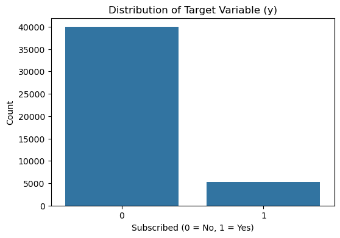

```python
# Target variable distribution
import matplotlib.pyplot as plt
import seaborn as sns

print("Target distribution:\n", data_clean["y"].value_counts())

plt.figure(figsize = (6,4))
sns.countplot(x = "y", data = data_clean)
plt.title("Distribution of Target Variable (y)")
plt.xlabel("Subscribed (0 = No, 1 = Yes)")
plt.ylabel("Count")
plt.show()
```

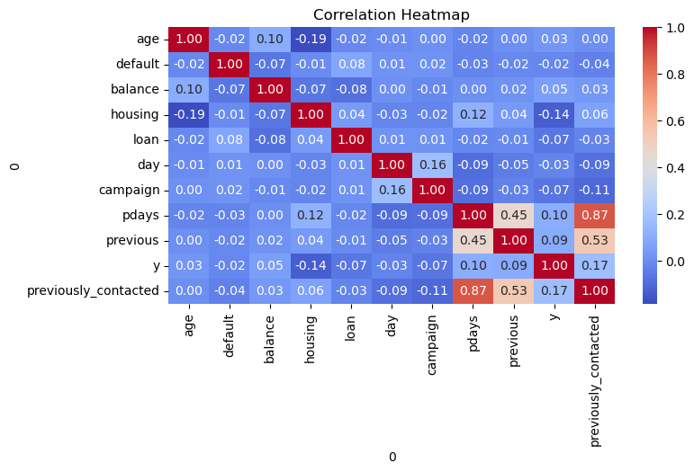

```python
# Correlation heatmap
plt.figure(figsize = (8, 4))
corr = data_clean.corr(numeric_only = True)
sns.heatmap(corr, annot = True, cmap = "coolwarm", fmt = ".2f")
plt.title("Correlation Heatmap")
plt.show()
```

## II. Model (only with the best prediction)

```python
from sklearn.model_selection import train_test_split
from sklearn.preprocessing import StandardScaler
from sklearn.metrics import accuracy_score, classification_report, confusion_matrix, roc_auc_score

from tensorflow.keras.models import Sequential
from tensorflow.keras.layers import Dense, Input
from sklearn.utils.class_weight import compute_class_weight
import tensorflow as tf
```

```python
X = data_clean.drop(columns = ["y"])
y = data_clean["y"]

X = pd.get_dummies(X, drop_first = True)
X_train, X_test, y_train, y_test = train_test_split(
    X,
    y,
    test_size = 0.2,
    random_state = 617,
    stratify = y
)
```

##### This part will conduct deep learning method for this dataset. For nerual networking processing, we used multiple layers mapping with ReLU and Sigmoid. The reason using ReLU is because the target value "y" is a binary value where eighter "0" or "1" in its output. To prepare for this modeling, numerical variables such as age, balance, day, campaign, pdays and previous should be standarlized before fitting the model.

```python
# Standard scale specific variables
scaled_cols = ["age", "balance", "day", "campaign", "pdays", "previous"]

scaler = StandardScaler()

X_train[scaled_cols] = scaler.fit_transform(X_train[scaled_cols])
X_test[scaled_cols] = scaler.transform(X_test[scaled_cols])
```

```python
classes = np.unique(y_train)
weights = compute_class_weight(class_weight = "balanced", classes = classes, y = y_train)
class_weight_dict = dict(zip(classes, weights))

model = Sequential([
    Input(shape = (X_train.shape[1],)),
    Dense(32, activation = "relu"),
    Dense(1, activation = "sigmoid")
])

model.compile(
    optimizer = "adam",
    loss = "binary_crossentropy",
    metrics=[
        "accuracy",
        tf.keras.metrics.AUC(name = "auc"),
        tf.keras.metrics.Precision(name = "precision"),
        tf.keras.metrics.Recall(name = "recall")
    ]
)
```

```python
history = model.fit(
    X_train, y_train,
    validation_split = 0.2,
    epochs = 30,
    batch_size = 32,
    class_weight = class_weight_dict,
    verbose = 1
)
```

```
905/905 ━━━━━━━━━━━━━━━━━━━━ 1s 637us/step - accuracy: 0.7184 - auc: 0.7278 - loss: 0.6050 - precision: 0.2285 - recall: 0.5967 - val_accuracy: 0.7433 - val_auc: 0.7750 - val_loss: 0.5827 - val_precision: 0.2682 - val_recall: 0.6690
905/905 ━━━━━━━━━━━━━━━━━━━━ 0s 437us/step - accuracy: 0.7721 - auc: 0.7706 - loss: 0.5656 - precision: 0.2840 - recall: 0.6291 - val_accuracy: 0.7625 - val_auc: 0.7863 - val_loss: 0.5637 - val_precision: 0.2863 - val_recall: 0.6667
905/905 ━━━━━━━━━━━━━━━━━━━━ 0s 438us/step - accuracy: 0.7773 - auc: 0.7790 - loss: 0.5576 - precision: 0.2909 - recall: 0.6344 - val_accuracy: 0.7846 - val_auc: 0.7915 - val_loss: 0.5472 - val_precision: 0.3063 - val_recall: 0.6400
905/905 ━━━━━━━━━━━━━━━━━━━━ 0s 437us/step - accuracy: 0.7829 - auc: 0.7854 - loss: 0.5519 - precision: 0.2976 - recall: 0.6350 - val_accuracy: 0.7997 - val_auc: 0.7931 - val_loss: 0.5219 - val_precision: 0.3229 - val_recall: 0.6225
905/905 ━━━━━━━━━━━━━━━━━━━━ 0s 455us/step - accuracy: 0.7850 - auc: 0.7895 - loss: 0.5479 - precision: 0.3015 - recall: 0.6427 - val_accuracy: 0.8040 - val_auc: 0.7940 - val_loss: 0.5167 - val_precision: 0.3263 - val_recall: 0.6074
905/905 ━━━━━━━━━━━━━━━━━━━━ 0s 459us/step - accuracy: 0.7868 - auc: 0.7922 - loss: 0.5449 - precision: 0.3035 - recall: 0.6412 - val_accuracy: 0.7615 - val_auc: 0.7958 - val_loss: 0.5633 - val_precision: 0.2878 - val_recall: 0.6806
905/905 ━━━━━━━━━━━━━━━━━━━━ 0s 446us/step - accuracy: 0.7861 - auc: 0.7958 - loss: 0.5414 - precision: 0.3047 - recall: 0.6522 - val_accuracy: 0.7657 - val_auc: 0.7954 - val_loss: 0.5585 - val_precision: 0.2919 - val_recall: 0.6794
905/905 ━━━━━━━━━━━━━━━━━━━━ 0s 437us/step - accuracy: 0.7848 - auc: 0.7974 - loss: 0.5390 - precision: 0.3030 - recall: 0.6519 - val_accuracy: 0.8015 - val_auc: 0.7968 - val_loss: 0.5123 - val_precision: 0.3265 - val_recall: 0.6283
905/905 ━━━━━━━━━━━━━━━━━━━━ 0s 437us/step - accuracy: 0.7884 - auc: 0.8002 - loss: 0.5362 - precision: 0.3064 - recall: 0.6463 - val_accuracy: 0.7790 - val_auc: 0.7952 - val_loss: 0.5416 - val_precision: 0.3037 - val_recall: 0.6632
905/905 ━━━━━━━━━━━━━━━━━━━━ 0s 436us/step - accuracy: 0.7871 - auc: 0.8024 - loss: 0.5344 - precision: 0.3069 - recall: 0.6579 - val_accuracy: 0.8070 - val_auc: 0.7981 - val_loss: 0.5080 - val_precision: 0.3342 - val_recall: 0.6260
905/905 ━━━━━━━━━━━━━━━━━━━━ 0s 436us/step - accuracy: 0.7884 - auc: 0.8036 - loss: 0.5327 - precision: 0.3077 - recall: 0.6531 - val_accuracy: 0.8074 - val_auc: 0.7968 - val_loss: 0.5131 - val_precision: 0.3346 - val_recall: 0.6249
905/905 ━━━━━━━━━━━━━━━━━━━━ 0s 434us/step - accuracy: 0.7920 - auc: 0.8050 - loss: 0.5316 - precision: 0.3123 - recall: 0.6534 - val_accuracy: 0.7653 - val_auc: 0.7982 - val_loss: 0.5632 - val_precision: 0.2931 - val_recall: 0.6887
905/905 ━━━━━━━━━━━━━━━━━━━━ 0s 472us/step - accuracy: 0.7905 - auc: 0.8069 - loss: 0.5297 - precision: 0.3117 - recall: 0.6611 - val_accuracy: 0.7967 - val_auc: 0.7996 - val_loss: 0.5217 - val_precision: 0.3233 - val_recall: 0.6481
905/905 ━━━━━━━━━━━━━━━━━━━━ 0s 453us/step - accuracy: 0.7920 - auc: 0.8082 - loss: 0.5281 - precision: 0.3133 - recall: 0.6596 - val_accuracy: 0.8134 - val_auc: 0.7994 - val_loss: 0.4899 - val_precision: 0.3424 - val_recall: 0.6167
905/905 ━━━━━━━━━━━━━━━━━━━━ 0s 453us/step - accuracy: 0.7920 - auc: 0.8094 - loss: 0.5271 - precision: 0.3122 - recall: 0.6531 - val_accuracy: 0.7828 - val_auc: 0.8003 - val_loss: 0.5281 - val_precision: 0.3089 - val_recall: 0.6667
905/905 ━━━━━━━━━━━━━━━━━━━━ 0s 505us/step - accuracy: 0.7923 - auc: 0.8113 - loss: 0.5252 - precision: 0.3143 - recall: 0.6629 - val_accuracy: 0.7743 - val_auc: 0.7972 - val_loss: 0.5439 - val_precision: 0.2998 - val_recall: 0.6713
905/905 ━━━━━━━━━━━━━━━━━━━━ 0s 447us/step - accuracy: 0.7911 - auc: 0.8119 - loss: 0.5241 - precision: 0.3120 - recall: 0.6588 - val_accuracy: 0.7910 - val_auc: 0.7984 - val_loss: 0.5239 - val_precision: 0.3156 - val_recall: 0.6469
905/905 ━━━━━━━━━━━━━━━━━━━━ 0s 465us/step - accuracy: 0.7929 - auc: 0.8137 - loss: 0.5227 - precision: 0.3149 - recall: 0.6617 - val_accuracy: 0.7676 - val_auc: 0.7978 - val_loss: 0.5468 - val_precision: 0.2929 - val_recall: 0.6736
905/905 ━━━━━━━━━━━━━━━━━━━━ 0s 437us/step - accuracy: 0.7948 - auc: 0.8139 - loss: 0.5220 - precision: 0.3167 - recall: 0.6585 - val_accuracy: 0.7698 - val_auc: 0.7983 - val_loss: 0.5421 - val_precision: 0.2976 - val_recall: 0.6864
905/905 ━━━━━━━━━━━━━━━━━━━━ 0s 437us/step - accuracy: 0.7931 - auc: 0.8155 - loss: 0.5211 - precision: 0.3159 - recall: 0.6665 - val_accuracy: 0.8103 - val_auc: 0.7977 - val_loss: 0.4907 - val_precision: 0.3367 - val_recall: 0.6121
```

[output cut: 10 more lines]

```
Loss Plot
```

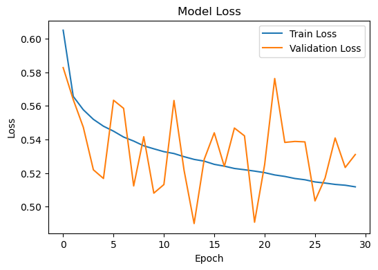

```
Accuracy Plot
```

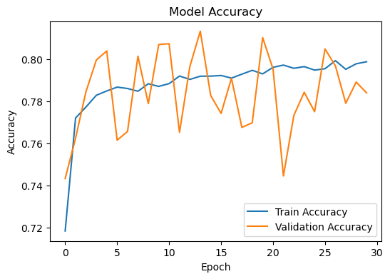

```
AUC Plot
```

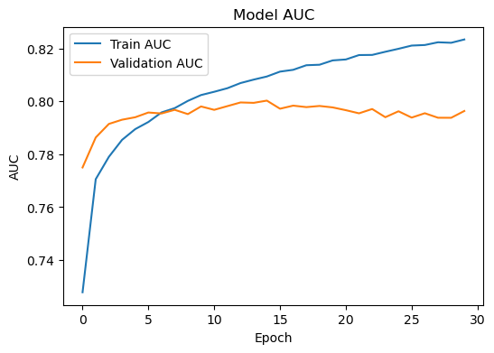

```python
print("Loss Plot\n")
plt.figure(figsize = (6,4))
plt.plot(history.history["loss"], label = "Train Loss")
plt.plot(history.history["val_loss"], label = "Validation Loss")
plt.title("Model Loss")
plt.xlabel("Epoch")
plt.ylabel("Loss")
plt.legend()
plt.show()

print("Accuracy Plot\n")
plt.figure(figsize = (6,4))
plt.plot(history.history["accuracy"], label = "Train Accuracy")
plt.plot(history.history["val_accuracy"], label = "Validation Accuracy")
plt.title("Model Accuracy")
plt.xlabel("Epoch")
plt.ylabel("Accuracy")
plt.legend()
plt.show()

print("AUC Plot\n")
plt.figure(figsize = (6,4))
plt.plot(history.history["auc"], label = "Train AUC")
plt.plot(history.history["val_auc"], label = "Validation AUC")
plt.title("Model AUC")
plt.xlabel("Epoch")
plt.ylabel("AUC")
plt.legend()
plt.show()
```

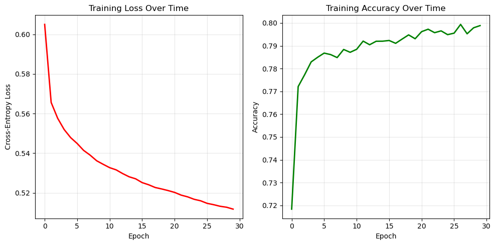

```python
fig, (ax1, ax2) = plt.subplots(1, 2, figsize = (10, 5))

# Plot 1: Training loss
ax1.plot(history.history["loss"], color = 'red', linewidth = 2)
ax1.set_xlabel('Epoch')
ax1.set_ylabel('Cross-Entropy Loss')
ax1.set_title('Training Loss Over Time')
ax1.grid(True, alpha = 0.3)

# Plot 2: Training accuracy
ax2.plot(history.history["accuracy"], color = 'green', linewidth = 2)
ax2.set_xlabel('Epoch')
ax2.set_ylabel('Accuracy')
ax2.set_title('Training Accuracy Over Time')
ax2.grid(True, alpha = 0.3)

plt.tight_layout()
plt.show()
```

```python
# fitting test
y_prob_k = model.predict(X_test).ravel()
y_pred_k = (y_prob_k >= 0.5).astype(int)

print("ROC-AUC:", roc_auc_score(y_test, y_prob_k))
print("\nClassification Report:\n")
print(classification_report(y_test, y_pred_k, labels = [0, 1], target_names = ["No", "Yes"]))
```

```
283/283 ━━━━━━━━━━━━━━━━━━━━ 0s 216us/step
ROC-AUC: 0.7909411313509617

Classification Report:

              precision    recall  f1-score   support

          No       0.95      0.81      0.87      7985
         Yes       0.31      0.66      0.42      1058

    accuracy                           0.79      9043
   macro avg       0.63      0.73      0.65      9043
weighted avg       0.87      0.79      0.82      9043
```

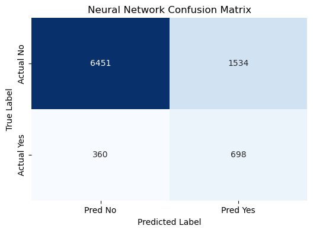

```python
# Confusion matrix
cm = confusion_matrix(
    y_test,
    y_pred_k
)

plt.figure(figsize = (6, 4))
sns.heatmap(
    cm,
    annot = True,
    fmt = 'd',
    cmap = 'Blues',
    xticklabels = ['Pred No', 'Pred Yes'],
    yticklabels = ['Actual No', 'Actual Yes'],
    cbar = False
)

plt.xlabel("Predicted Label")
plt.ylabel("True Label")
plt.title("Neural Network Confusion Matrix")
plt.show()
```

## III. Conclusion

##### The model achieved an overall test accuracy approximate to 80%, this is an acceptable general predictive performance. However, because the dataset is imbalanced, the class specific metrics provide a more meaningful evaluation. The model performed much better on the majority No class than on the minority Yes class. For the Yes class, recall reached 0.66, showing that the model was able to identify a moderate proportion of actual subscribers, but precision was only 0.31, means that many predicted positive cases were incorrect. This suggests that the model is more useful for broad screening of potential subscribers than for highly accurate positive targeting.